# Lista 2 planejamento 2

Clevia Bento de Oliveira

30/09/2021

# Questão 1 pagina 1

Delineamento em blocos casualizados com dois fatores, Doses e aplicações. Sendo 4 tipos de doses diferentes ( 0, 40 , 80 , 120 ) e 3 tipos de aplicações (colva(b1) , sulco(b2) e lanço(b3)) e 4 blocos.

## inserindo os dados

```r
y <- c(2.778,2.467,2.422,3.302,3.653,3.711,
       2.938,3.900,2.702,3.013,3.338,3.156,
       2.618,3.284,2.760,2.671,2.653,3.284,
       2.813,4.356,3.520,3.787,3.369,4.369,
       1.164,2.773,1.747,2.782,3.529,2.556,
       2.560,3.560,3.382,3.142,2.507,2.831,
       2.996,2.280,1.853,2.502,2.258,3.284,
       3.049,4.013,3.524,3.604,4.200,4.222)
n = length(y)
t <- 12
b <- 4

bloco<- factor(rep(c("B1","B2","B3","B4"),time=c(t,t,t,t))); bloco
```

```
##  [1] B1 B1 B1 B1 B1 B1 B1 B1 B1 B1 B1 B1 B2 B2 B2 B2 B2 B2 B2 B2 B2 B2 B2 B2 B3
## [26] B3 B3 B3 B3 B3 B3 B3 B3 B3 B3 B3 B4 B4 B4 B4 B4 B4 B4 B4 B4 B4 B4 B4
## Levels: B1 B2 B3 B4
```

```r
parcelas<- factor(1:n); parcelas
```

```
##  [1] 1  2  3  4  5  6  7  8  9  10 11 12 13 14 15 16 17 18 19 20 21 22 23 24 25
## [26] 26 27 28 29 30 31 32 33 34 35 36 37 38 39 40 41 42 43 44 45 46 47 48
## 48 Levels: 1 2 3 4 5 6 7 8 9 10 11 12 13 14 15 16 17 18 19 20 21 22 23 ... 48
```

```r
k = 4
j = 3

doses<- factor(rep(c(1:k), each=j, times=b), labels=c("0","40","80","120"))
tipo_app<- factor(rep(c(1:3), times= k*b), labels=c("colva","sulco","lanco"))
trat<- factor(rep(c(1:t), time=b), labels=c("T1","T2","T3","T4","T5","T6","T7","T8","T9","T10","T11","T12"))

DBC<- data.frame(parcelas,bloco,doses,tipo_app,trat,y);  DBC
```

```
##    parcelas bloco doses tipo_app trat     y
## 1         1    B1     0    colva   T1 2.778
## 2         2    B1     0    sulco   T2 2.467
## 3         3    B1     0    lanco   T3 2.422
## 4         4    B1    40    colva   T4 3.302
## 5         5    B1    40    sulco   T5 3.653
## 6         6    B1    40    lanco   T6 3.711
## 7         7    B1    80    colva   T7 2.938
## 8         8    B1    80    sulco   T8 3.900
## 9         9    B1    80    lanco   T9 2.702
## 10       10    B1   120    colva  T10 3.013
## 11       11    B1   120    sulco  T11 3.338
## 12       12    B1   120    lanco  T12 3.156
## 13       13    B2     0    colva   T1 2.618
## 14       14    B2     0    sulco   T2 3.284
```

[output cut: 34 more lines]

## Análise descritiva

interação entre os fatores.

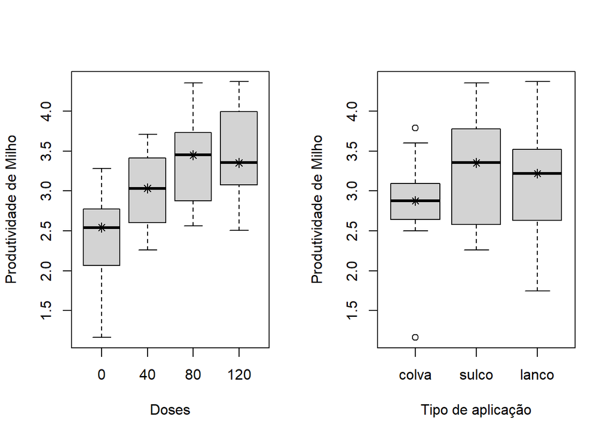

```r
par(mfrow=c(1,2))
boxplot(split(y,doses),   style.bxp="old", xlab="Doses",  ylab="Produtividade de Milho", medchar = T, medpch = 8)
boxplot(split(y,tipo_app), style.bxp="old", xlab="Tipo de aplicação", ylab="Produtividade de Milho", medchar = T, medpch = 8)
```

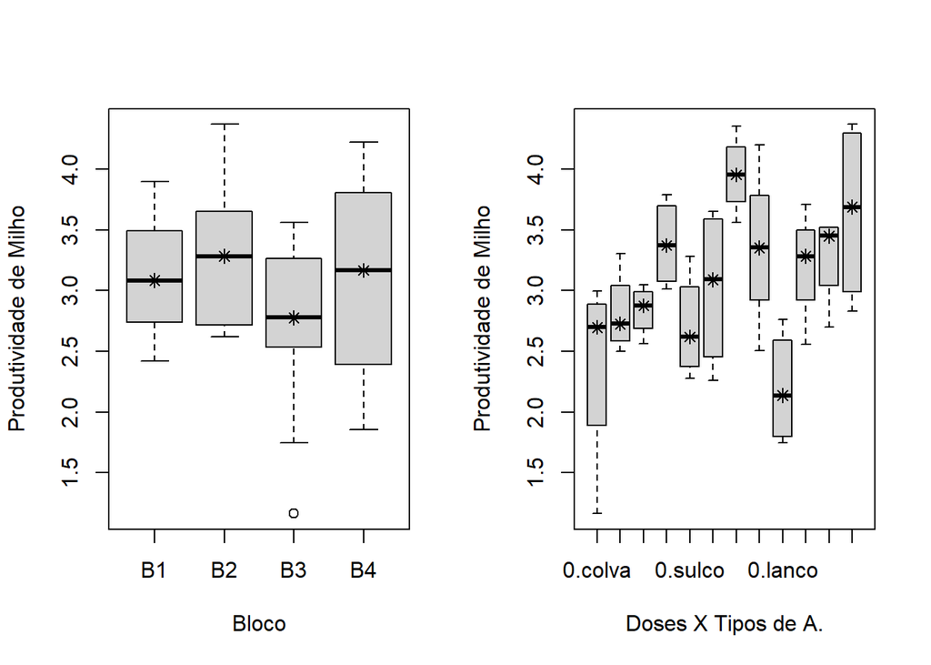

```r
par(mfrow=c(1,2))
boxplot(split(y,bloco),     style.bxp="old", xlab="Bloco",     ylab="Produtividade de Milho", medchar = T, medpch = 8)
boxplot((y~doses*tipo_app), style.bxp="old", xlab="Doses X Tipos de A.", ylab="Produtividade de Milho", medchar = T, medpch = 8)
```

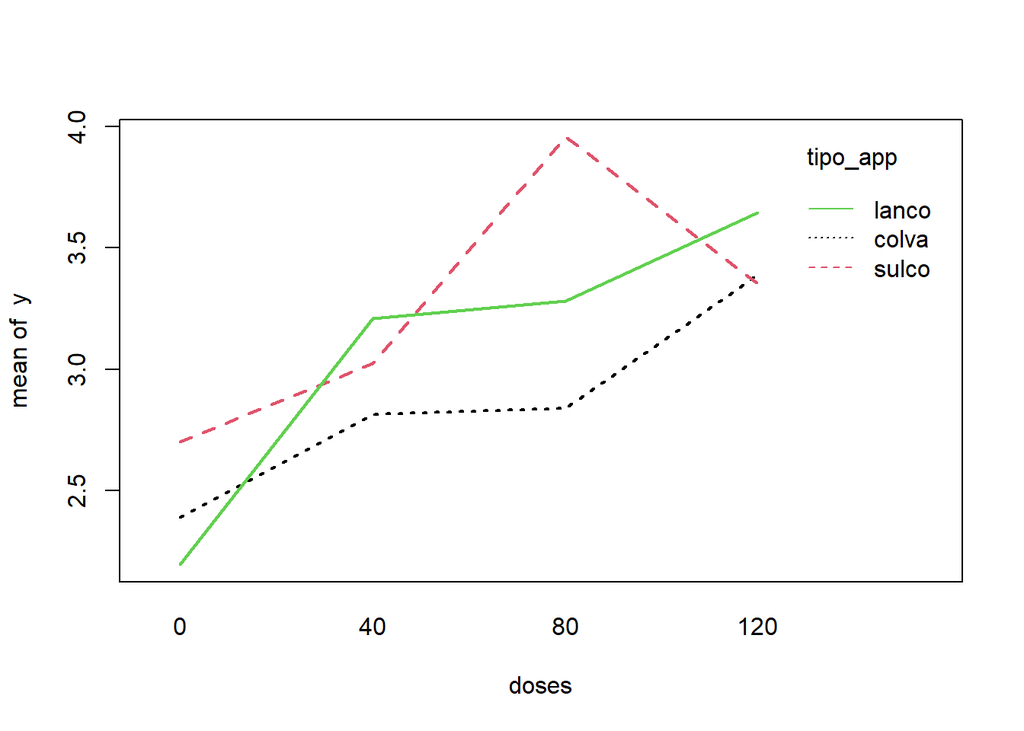

```r
par(mfrow=c(1,1))
interaction.plot(doses,tipo_app,y, lwd=2, col= c("1", "2", "3"))
```

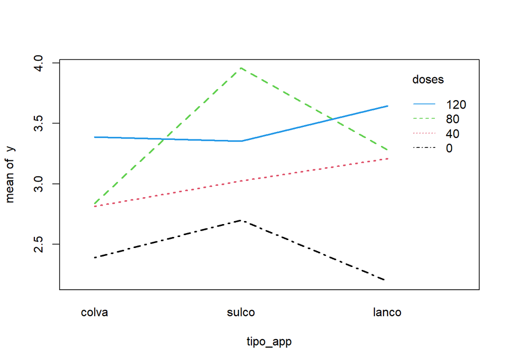

```r
interaction.plot(tipo_app,doses,y, lwd=2, col= c("1", "2", "3","4"))
```

## Média Variância e Desvio Padrão

```r
Var_doses<-  tapply(y,doses,var)
Var_tipo_app<- tapply(y,tipo_app,var)
Var_trat<- tapply(y,trat,var)

Media_doses<-  tapply(y,doses,mean)
Media_tipo_app<- tapply(y,tipo_app,mean)
Media_trat<- tapply(y,trat,mean)

Desvio_pad_doses<- sqrt(Var_doses)
Desvio_pad_tipo_app<- sqrt(Var_tipo_app)
Desvio_pad_trat<- sqrt(Var_trat)

V_doses<-data.frame(Var_doses, Media_doses, Desvio_pad_doses);  V_doses
```

```
##     Var_doses Media_doses Desvio_pad_doses
## 0   0.3507954    2.428500        0.5922798
## 40  0.2484830    3.015417        0.4984807
## 80  0.3136347    3.359750        0.5600310
## 120 0.3456843    3.461500        0.5879492
```

```r
V_tipo_app<- data.frame(Var_tipo_app, Media_tipo_app, Desvio_pad_tipo_app); V_tipo_app
```

```
##       Var_tipo_app Media_tipo_app Desvio_pad_tipo_app
## colva    0.3316827       2.857438           0.5759190
## sulco    0.4775087       3.258750           0.6910201
## lanco    0.5487948       3.082688           0.7408068
```

```r
V_trat<- data.frame(Var_trat, Media_trat, Desvio_pad_trat); V_trat
```

```
##      Var_trat Media_trat Desvio_pad_trat
## T1  0.6909453    2.38900       0.8312312
## T2  0.1923567    2.70100       0.4385848
## T3  0.2294737    2.19550       0.4790341
## T4  0.1189869    2.81425       0.3449448
## T5  0.4583536    3.02325       0.6770182
## T6  0.2298876    3.20875       0.4794659
## T7  0.0441380    2.84000       0.2100905
## T8  0.1077316    3.95725       0.3282249
## T9  0.1538693    3.28200       0.3922618
## T10 0.1356630    3.38650       0.3683246
## T11 0.4778683    3.35350       0.6912802
## T12 0.5862737    3.64450       0.7656851
```

## Anova

```r
produt.lm <- lm(y ~ bloco + doses*tipo_app)
anova(produt.lm , test="F")
```

```
## Analysis of Variance Table
##
## Response: y
##                Df Sum Sq Mean Sq F value   Pr(>F)
## bloco           3 2.2265 0.74216  3.0423  0.04251 *
## doses           3 7.8201 2.60670 10.6856 4.63e-05 ***
## tipo_app        2 1.2949 0.64743  2.6540  0.08535 .
## doses:tipo_app  6 2.2731 0.37884  1.5530  0.19209
## Residuals      33 8.0502 0.24394
## ---
## Signif. codes:  0 '***' 0.001 '**' 0.01 '*' 0.05 '.' 0.1 ' ' 1
```

```r
LP2 <- (predict(produt.lm))^2      # = u
produt.lm2 <-update(produt.lm, .~. +LP2)
anova(produt.lm, produt.lm2, test="F")
```

```
## Analysis of Variance Table
##
## Model 1: y ~ bloco + doses * tipo_app
## Model 2: y ~ bloco + doses + tipo_app + LP2 + doses:tipo_app
##   Res.Df    RSS Df Sum of Sq      F Pr(>F)
## 1     33 8.0502
## 2     32 8.0458  1 0.0043307 0.0172 0.8964
```

## Teste Tukey

```r
require(laercio)
prodt_doses <- aov(y~bloco + doses*tipo_app)
LTukey(prodt_doses, which = "trat", conf.level = 0.95)
```

```
##
##  TUKEY TEST TO COMPARE MEANS
##
##  Confidence level:  0.95
##  Dependent variable:  y
##  Variation Coefficient:  16.10765 %
##
## Independent variable:  bloco
##   Factors Means
##   B2      3.29033333333333 a
##   B4      3.14875          ab
##   B1      3.115            ab
##   B3      2.71108333333333  b
##
##
## Independent variable:  doses
##   Factors Means
##   120     3.4615           a
##   80      3.35975          a
##   40      3.01541666666667 a
##   0       2.4285            b
##
##
## Independent variable:  tipo_app
##   Factors Means
##   sulco   3.25875   a
##   lanco   3.0826875 a
##   colva   2.8574375 a
##
##
```

## analise de resíduos e o teste de normalidade de Shapiro-Wilk.

```r
fit            <- fitted(produt.lm)     # valores ajustados
res            <- residuals(produt.lm)  # resíduos ordinários
res_padronizado<- rstandard(produt.lm)  # resíduos padronizados
res_student    <- rstudent(produt.lm)   # resíduos studentizados

data.frame(parcelas, trat, y, res, res_padronizado, res_student, fit)
```

```
##    parcelas trat     y          res res_padronizado res_student      fit
## 1         1   T1 2.778  0.340291667      0.83093956  0.82694960 2.437708
## 2         2   T2 2.467 -0.282708333     -0.69032998 -0.68475223 2.749708
## 3         3   T3 2.422  0.177791667      0.43413972  0.42873735 2.244208
## 4         4   T4 3.302  0.439041667      1.07207177  1.07458214 2.862958
## 5         5   T5 3.653  0.581041667      1.41881378  1.44181935 3.071958
## 6         6   T6 3.711  0.453541667      1.10747853  1.11141904 3.257458
## 7         7   T7 2.938  0.049291667      0.12036262  0.11855094 2.888708
## 8         8   T8 3.900 -0.105958333     -0.25873384 -0.25504230 4.005958
## 9         9   T9 2.702 -0.628708333     -1.53520840 -1.56882944 3.330708
## 10       10  T10 3.013 -0.422208333     -1.03096738 -1.03198202 3.435208
## 11       11  T11 3.338 -0.064208333     -0.15678681 -0.15445051 3.402208
## 12       12  T12 3.156 -0.537208333     -1.31177957 -1.32680713 3.693208
## 13       13   T1 2.618  0.004958333      0.01210748  0.01192265 2.613042
## 14       14   T2 3.284  0.358958333      0.87652067  0.87336436 2.925042
```

[output cut: 34 more lines]

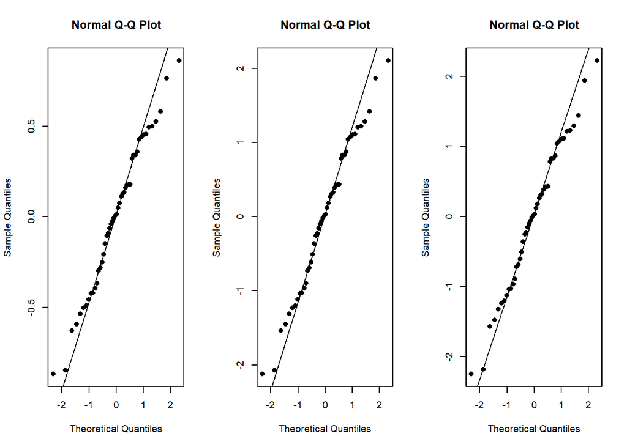

```r
par(mfrow=c(1,3))
qqnorm(res, pch=16);                qqline(res)
qqnorm(res_padronizado, pch=16);    qqline(res_padronizado)
qqnorm(res_student, pch=16);        qqline(res_student)
```

```r
# Teste de normalidade Shapiro Wilk


# H0: É normal
# Ha: Não é normal


shapiro.test(produt.lm$res)
```

```
##
##  Shapiro-Wilk normality test
##
## data:  produt.lm$res
## W = 0.98382, p-value = 0.7418
```

# Questão 6 pagina 3

## inserindo os dados

Experimento DBC com dois fatores A e B e 4 repetições

```r
rm(list=ls())
y <- c(25.4,32.9,26.1,35.2,
       25.6,34.7,25.9,35.8,14.6,
       25.2,14.3,25.5,15.5,24.7,15.6,24.8)
n = length(y)
t <- 4
b <- 4

bloco<- factor(rep(c("1","2","3","4"),times=4))
parcelas<- factor(1:n)

k = 2
j = 2

A<- factor(rep(c(1:k), each=8), labels=c('A1',"A2"))
B<- factor(rep(c(1:2), each=4, times= j), labels=c("B1","B2"))
trat<- factor(rep(c(1:t),each=b), labels=c("T1","T2","T3","T4"))

DBC<- data.frame(parcelas,bloco,A,B,trat,y);  DBC
```

```
##    parcelas bloco  A  B trat    y
## 1         1     1 A1 B1   T1 25.4
## 2         2     2 A1 B1   T1 32.9
## 3         3     3 A1 B1   T1 26.1
## 4         4     4 A1 B1   T1 35.2
## 5         5     1 A1 B2   T2 25.6
## 6         6     2 A1 B2   T2 34.7
## 7         7     3 A1 B2   T2 25.9
## 8         8     4 A1 B2   T2 35.8
## 9         9     1 A2 B1   T3 14.6
## 10       10     2 A2 B1   T3 25.2
## 11       11     3 A2 B1   T3 14.3
## 12       12     4 A2 B1   T3 25.5
## 13       13     1 A2 B2   T4 15.5
## 14       14     2 A2 B2   T4 24.7
## 15       15     3 A2 B2   T4 15.6
## 16       16     4 A2 B2   T4 24.8
```

## Análise descritiva

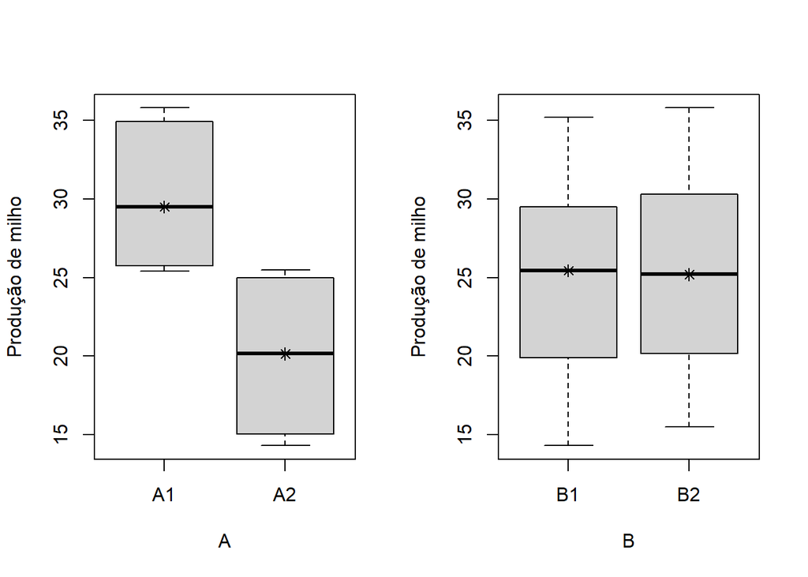

```r
par(mfrow=c(1,2))
boxplot(split(y,A),   style.bxp="old", xlab="A",  ylab="Produção de milho", medchar = T, medpch = 8)
boxplot(split(y,B), style.bxp="old", xlab="B", ylab="Produção de milho", medchar = T, medpch = 8)
```

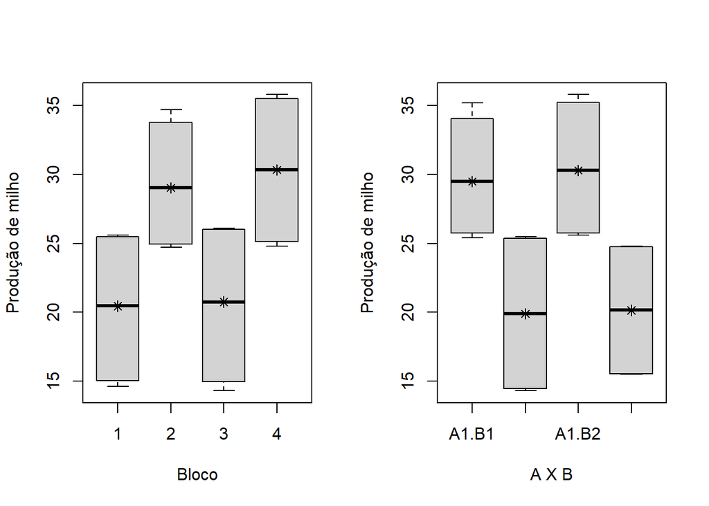

```r
par(mfrow=c(1,2))
boxplot(split(y,bloco),     style.bxp="old", xlab="Bloco",     ylab="Produção de milho", medchar = T, medpch = 8)
boxplot((y~A*B), style.bxp="old", xlab="A X B", ylab="Produção de milho", medchar = T, medpch = 8)
```

## Anova

```r
germ.lm <- lm(y ~ bloco + A*B)
anova(germ.lm , test="F")
```

```
## Analysis of Variance Table
##
## Response: y
##           Df Sum Sq Mean Sq  F value    Pr(>F)
## bloco      3 360.99  120.33 206.5737 1.292e-08 ***
## A          1 414.12  414.12 710.9399 7.100e-10 ***
## B          1   0.72    0.72   1.2403    0.2943
## A:B        1   0.12    0.12   0.2103    0.6574
## Residuals  9   5.24    0.58
## ---
## Signif. codes:  0 '***' 0.001 '**' 0.01 '*' 0.05 '.' 0.1 ' ' 1
```

```r
LP2 <- (predict(germ.lm))^2
germ.lm2 <-update(germ.lm, .~. +LP2)
anova(germ.lm, germ.lm2, test="F")
```

```
## Analysis of Variance Table
##
## Model 1: y ~ bloco + A * B
## Model 2: y ~ bloco + A + B + LP2 + A:B
##   Res.Df    RSS Df Sum of Sq      F Pr(>F)
## 1      9 5.2425
## 2      8 4.1356  1    1.1069 2.1413 0.1815
```

Podemos ver que o efeito do fator A e do Bloco são significativos Ou seja há diferença na produção em relação de milho em relação com a quantidade de agua.

## Teste Tukey

```r
require(laercio)
prodt_doses <- aov(y~bloco + A*B)
LTukey(prodt_doses, which = "trat", conf.level = 0.95)
```

```
##
##  TUKEY TEST TO COMPARE MEANS
##
##  Confidence level:  0.95
##  Dependent variable:  y
##  Variation Coefficient:  3.039191 %
##
## Independent variable:  bloco
##   Factors Means
##   4       30.325 a
##   2       29.375 a
##   3       20.475  b
##   1       20.275  b
##
##
## Independent variable:  A
##   Factors Means
##   A1      30.2   a
##   A2      20.025  b
##
##
## Independent variable:  B
##   Factors Means
##   B2      25.325 a
##   B1      24.9   a
##
##
```

# Questão da pagina 4

experimento em blocos no esquema fatorial subdivido 2 fatores tipos de cultivares sendo eles: emgopa, embrapa, rainha e itiquira. E época de semeadura sendo eles: agosto, setembro, outubro, novembro e dezembro.  
Com 3 blocos

## inserindo os dados

```r
rm(list=ls(all=TRUE))
y = c(61,40,74,37,71,50,84,47,81,60,94,57,90,92,96,90,86,90,90,91,
      57,36,70,33,67,46,80,43,77,56,90,53,94,96,99,94,82,94,94,95,
      55,44,77,41,75,54,87,51,85,64,97,61,86,88,92,86,90,86,86,87)
n = length(y)
t <- 20
b <- 3

bloco<- factor(rep(c("B1","B2","B3"),time=c(t,t,t)))
parcelas<- factor(1:n)

k = 4
j = 5

cult<- factor(rep(c(1:k), each=j, times=b), labels=c("emgopa","embrapa","rainha","itiquira"))
epoca<- factor(rep(c(1:5), times= k*b), labels=c("AGO","SET","OUT","NOV","DEZ"))
trat<- factor(rep(c(1:t), time=b), labels=c("T1","T2","T3","T4","T5","T6","T7","T8","T9","T10","T11","T12","T13","T14","T15","T16","T17","T18","T19","T20"))

DBC<- data.frame(parcelas,bloco,cult,epoca,trat,y);  DBC
```

```
##    parcelas bloco     cult epoca trat  y
## 1         1    B1   emgopa   AGO   T1 61
## 2         2    B1   emgopa   SET   T2 40
## 3         3    B1   emgopa   OUT   T3 74
## 4         4    B1   emgopa   NOV   T4 37
## 5         5    B1   emgopa   DEZ   T5 71
## 6         6    B1  embrapa   AGO   T6 50
## 7         7    B1  embrapa   SET   T7 84
## 8         8    B1  embrapa   OUT   T8 47
## 9         9    B1  embrapa   NOV   T9 81
## 10       10    B1  embrapa   DEZ  T10 60
## 11       11    B1   rainha   AGO  T11 94
## 12       12    B1   rainha   SET  T12 57
## 13       13    B1   rainha   OUT  T13 90
## 14       14    B1   rainha   NOV  T14 92
```

[output cut: 46 more lines]

## Analise descritiva

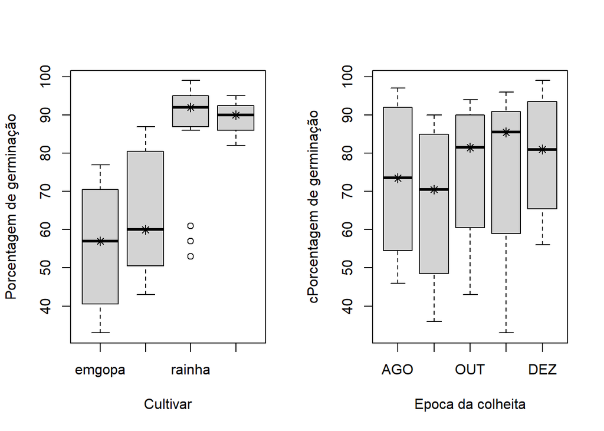

```r
par(mfrow=c(1,2))
boxplot(split(y,cult),   style.bxp="old", xlab="Cultivar",  ylab="Porcentagem de germinação", medchar = T, medpch = 8)
boxplot(split(y,epoca), style.bxp="old", xlab="Epoca da colheita", ylab="cPorcentagem de germinação", medchar = T, medpch = 8)
```

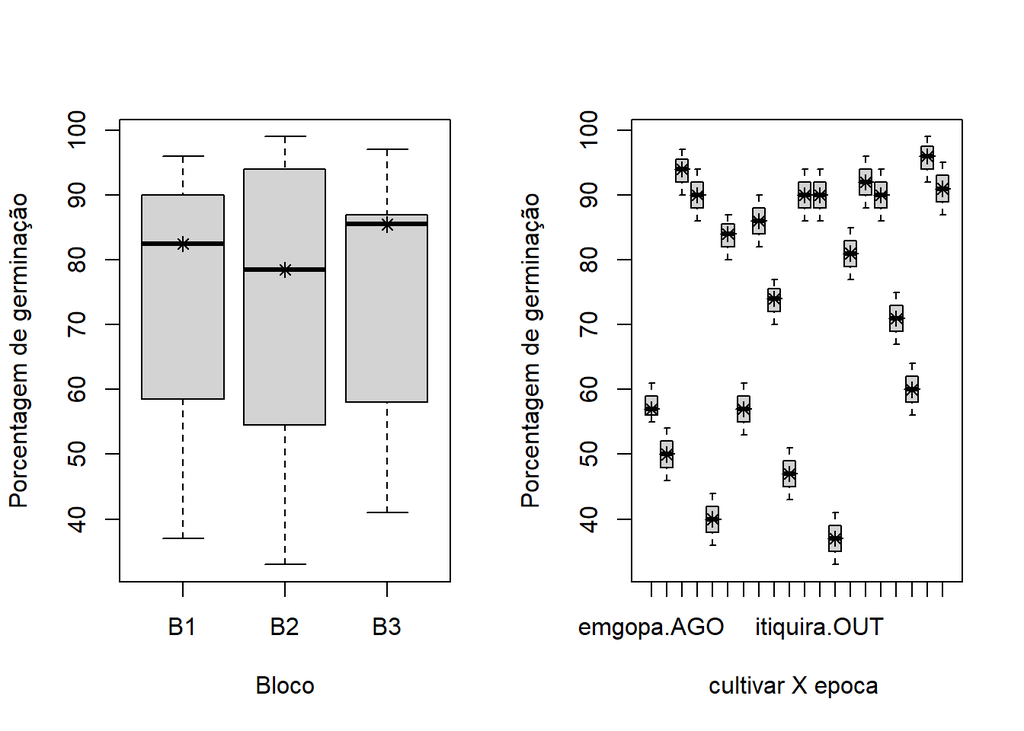

```r
par(mfrow=c(1,2))
boxplot(split(y,bloco),     style.bxp="old", xlab="Bloco",     ylab="Porcentagem de germinação", medchar = T, medpch = 8)
boxplot((y~cult*epoca), style.bxp="old", xlab="cultivar X epoca ", ylab="Porcentagem de germinação", medchar = T, medpch = 8)
```

## Gráfico de interação

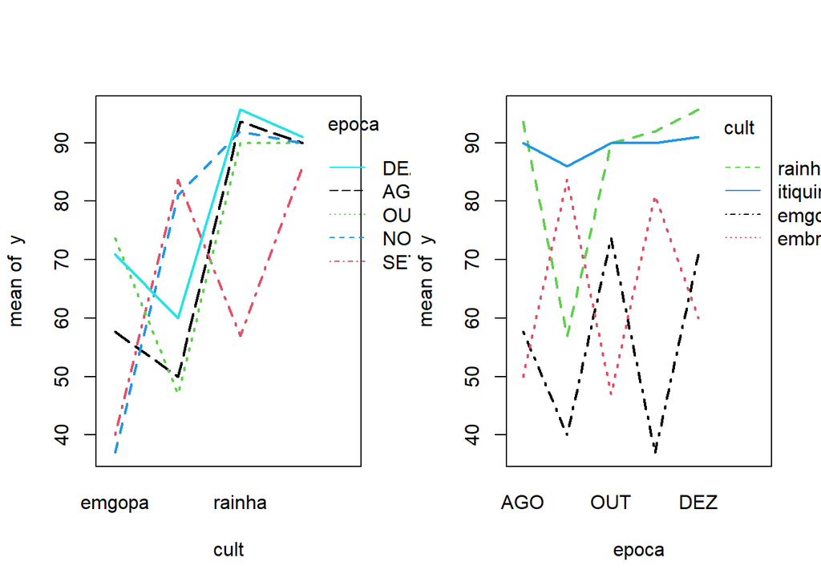

```r
par(mfrow=c(1,2))
interaction.plot(cult,epoca,y, lwd=2,col=c("1","2","3","4","5"))
interaction.plot(epoca,cult,y, lwd=2,col=c("1","2","3","4"))
```

## Anova

```r
mod.lm <- lm(y ~ bloco + cult*epoca)
anova(mod.lm , test="F")
```

```
## Analysis of Variance Table
##
## Response: y
##            Df  Sum Sq Mean Sq  F value    Pr(>F)
## bloco       2    34.0    17.0   1.1479     0.328
## cult        3 11931.0  3977.0 268.2865 < 2.2e-16 ***
## epoca       4  1040.1   260.0  17.5406 3.112e-08 ***
## cult:epoca 12  9138.6   761.6  51.3739 < 2.2e-16 ***
## Residuals  38   563.3    14.8
## ---
## Signif. codes:  0 '***' 0.001 '**' 0.01 '*' 0.05 '.' 0.1 ' ' 1
```

## Teste Tukey

```r
require(laercio)
mod3  <- aov(y~bloco + cult*epoca)
LTukey(mod3, which = "trat", conf.level = 0.95)
```

```
##
##  TUKEY TEST TO COMPARE MEANS
##
##  Confidence level:  0.95
##  Dependent variable:  y
##  Variation Coefficient:  5.215833 %
##
## Independent variable:  bloco
##   Factors Means
##   B3      74.6  a
##   B1      74.05 a
##   B2      72.8  a
##
##
## Independent variable:  cult
##   Factors  Means
##   itiquira 89.4             a
##   rainha   85.6666666666667 a
##   embrapa  64.3333333333333  b
##   emgopa   55.8666666666667   c
##
##
## Independent variable:  epoca
##   Factors Means
##   DEZ     79.4166666666667 a
##   OUT     75.1666666666667 ab
##   NOV     75               ab
##   AGO     72.8333333333333  b
##   SET     66.6666666666667   c
##
##
```

# Questão 2

experimento em blocos no esquema fatorial subdivido com 2 fatores Cultivar e Época de semeadura e 3 blocos.

## inserindo os dados

```r
y <- c(81,60,94,57,90,92,96,90,86,90,90,91,
       77,56,90,53,94,96,99,94,82,94,94,95,
       85,64,97,61,86,88,92,86,90,86,86,87)

n = length(y)
t <- 12
b <- 3

bloco<- factor(rep(c("B1","B2","B3"),time=c(t,t,t)))
parcelas<- factor(1:n)

k = 4
j = 3

cult<- factor(rep(c(1:k), each=j, times=b), labels=c("E316","Emb1","rai","iti"))
epoca<- factor(rep(c(1:3), times= k*b), labels=c("OUT","NOV","DEZ"))
trat<- factor(rep(c(1:t), time=b), labels=c("T1","T2","T3","T4","T5","T6","T7","T8","T9","T10","T11","T12"))

DBC<- data.frame(parcelas,bloco,cult,epoca,trat,y);  DBC
```

```
##    parcelas bloco cult epoca trat  y
## 1         1    B1 E316   OUT   T1 81
## 2         2    B1 E316   NOV   T2 60
## 3         3    B1 E316   DEZ   T3 94
## 4         4    B1 Emb1   OUT   T4 57
## 5         5    B1 Emb1   NOV   T5 90
## 6         6    B1 Emb1   DEZ   T6 92
## 7         7    B1  rai   OUT   T7 96
## 8         8    B1  rai   NOV   T8 90
## 9         9    B1  rai   DEZ   T9 86
## 10       10    B1  iti   OUT  T10 90
## 11       11    B1  iti   NOV  T11 90
## 12       12    B1  iti   DEZ  T12 91
## 13       13    B2 E316   OUT   T1 77
## 14       14    B2 E316   NOV   T2 56
```

[output cut: 22 more lines]

## Análise descritiva

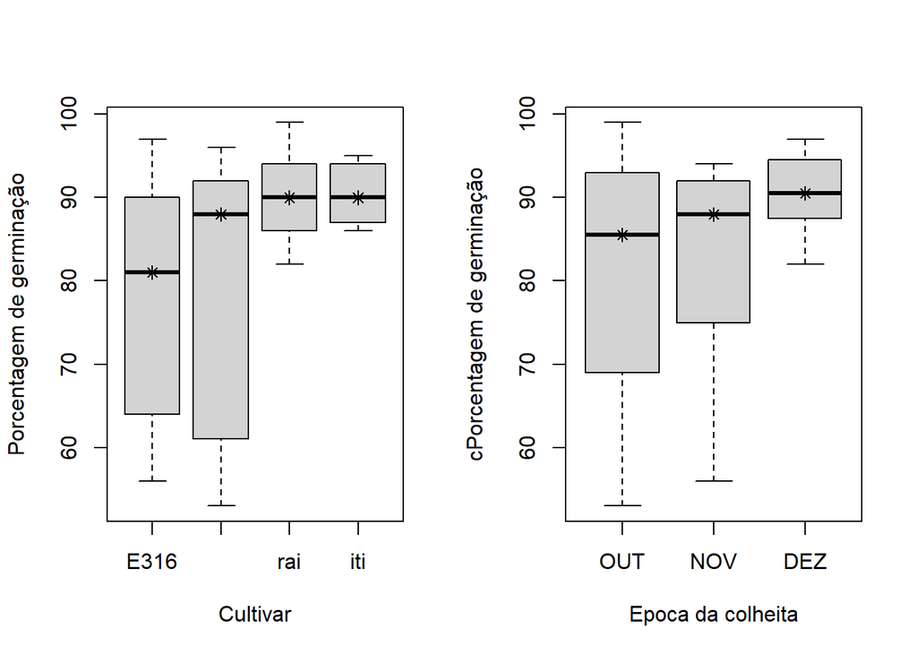

```r
par(mfrow=c(1,2))
boxplot(split(y,cult),   style.bxp="old", xlab="Cultivar",  ylab="Porcentagem de germinação", medchar = T, medpch = 8)
boxplot(split(y,epoca), style.bxp="old", xlab="Epoca da colheita", ylab="cPorcentagem de germinação", medchar = T, medpch = 8)
```

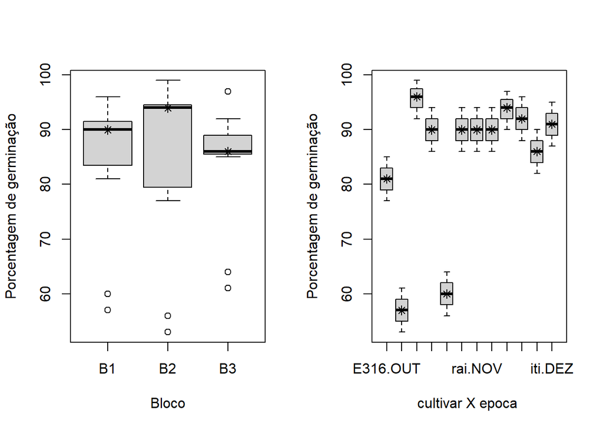

```r
par(mfrow=c(1,2))
boxplot(split(y,bloco),     style.bxp="old", xlab="Bloco",     ylab="Porcentagem de germinação", medchar = T, medpch = 8)
boxplot((y~cult*epoca), style.bxp="old", xlab="cultivar X epoca ", ylab="Porcentagem de germinação", medchar = T, medpch = 8)
```

## Gráfico de interação

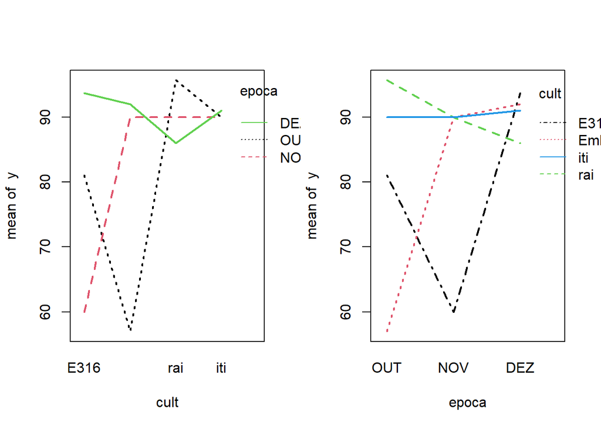

```r
par(mfrow=c(1,2))
interaction.plot(cult,epoca,y, lwd=2,col=c("1","2","3"))
interaction.plot(epoca,cult,y, lwd=2,col=c("1","2","3","4"))
```

# Anova

```r
germ.lm <- lm(y ~ bloco + epoca*cult)
anova(germ.lm , test="F")
```

```
## Analysis of Variance Table
##
## Response: y
##            Df Sum Sq Mean Sq F value    Pr(>F)
## bloco       2   10.7    5.36  0.3289    0.7232
## epoca       2  657.1  328.53 20.1545 1.063e-05 ***
## cult        3 1199.9  399.95 24.5363 3.290e-07 ***
## epoca:cult  6 3539.4  589.90 36.1889 2.613e-10 ***
## Residuals  22  358.6   16.30
## ---
## Signif. codes:  0 '***' 0.001 '**' 0.01 '*' 0.05 '.' 0.1 ' ' 1
```

```r
LP2 <- (predict(germ.lm))^2
germ.lm2 <-update(germ.lm, .~. +LP2)
anova(germ.lm, germ.lm2, test="F")
```

```
## Analysis of Variance Table
##
## Model 1: y ~ bloco + epoca * cult
## Model 2: y ~ bloco + epoca + cult + LP2 + epoca:cult
##   Res.Df    RSS Df Sum of Sq      F    Pr(>F)
## 1     22 358.61
## 2     21 210.55  1    148.06 14.767 0.0009456 ***
## ---
## Signif. codes:  0 '***' 0.001 '**' 0.01 '*' 0.05 '.' 0.1 ' ' 1
```

## Teste de Tukey

```r
require(laercio)
prodt_doses <- aov(y~bloco + epoca*cult)
LTukey(prodt_doses, which = "trat", conf.level = 0.95)
```

```
##
##  TUKEY TEST TO COMPARE MEANS
##
##  Confidence level:  0.95
##  Dependent variable:  y
##  Variation Coefficient:  4.767005 %
##
## Independent variable:  bloco
##   Factors Means
##   B2      85.3333333333333 a
##   B1      84.75            a
##   B3      84               a
##
##
## Independent variable:  epoca
##   Factors Means
##   DEZ     90.6666666666667 a
##   NOV     82.5              b
##   OUT     80.9166666666667  b
##
##
## Independent variable:  cult
##   Factors Means
##   rai     90.5555555555556 a
##   iti     90.3333333333333 a
##   Emb1    79.6666666666667  b
##   E316    78.2222222222222  b
##
##
```

# Questão 3

experimento em blocos no esquema fatorial subdivido com 2 fatores 3 cultivares sendo eles: A, B e C. E 3 níveis de irrigação sendo eles: 0 (B1), 40 (B2) e 80 (B3). ## inserindo os dados

```r
rm(list=ls(all=TRUE))

y <- c(75,81,84,80,84,90,79,87,96,
       83,85,90,82,89,93,82,93,97,
       74,80,85,80,83,89,78,88,95)


n = length(y)
t <- 9
b <- 3

bloco<- factor(rep(c("B1","B2","B3"),time=c(t,t,t)))
parcelas<- factor(1:n)

k = 3
j = 3


cult<- factor(rep(c(1:k), each=j, times=b), labels=c("A","B","C"))
irr<- factor(rep(c(1:3), times= k*b), labels=c("0","40","80"))
trat<- factor(rep(c(1:t), time=b), labels=c("T1","T2","T3","T4","T5","T6","T7","T8","T9"))

DBC<- data.frame(parcelas,bloco,cult,irr,trat,y);  DBC
```

```
##    parcelas bloco cult irr trat  y
## 1         1    B1    A   0   T1 75
## 2         2    B1    A  40   T2 81
## 3         3    B1    A  80   T3 84
## 4         4    B1    B   0   T4 80
## 5         5    B1    B  40   T5 84
## 6         6    B1    B  80   T6 90
## 7         7    B1    C   0   T7 79
## 8         8    B1    C  40   T8 87
## 9         9    B1    C  80   T9 96
## 10       10    B2    A   0   T1 83
## 11       11    B2    A  40   T2 85
## 12       12    B2    A  80   T3 90
## 13       13    B2    B   0   T4 82
## 14       14    B2    B  40   T5 89
## 15       15    B2    B  80   T6 93
## 16       16    B2    C   0   T7 82
## 17       17    B2    C  40   T8 93
## 18       18    B2    C  80   T9 97
## 19       19    B3    A   0   T1 74
## 20       20    B3    A  40   T2 80
## 21       21    B3    A  80   T3 85
## 22       22    B3    B   0   T4 80
## 23       23    B3    B  40   T5 83
## 24       24    B3    B  80   T6 89
## 25       25    B3    C   0   T7 78
## 26       26    B3    C  40   T8 88
## 27       27    B3    C  80   T9 95
```

## Análise descritiva

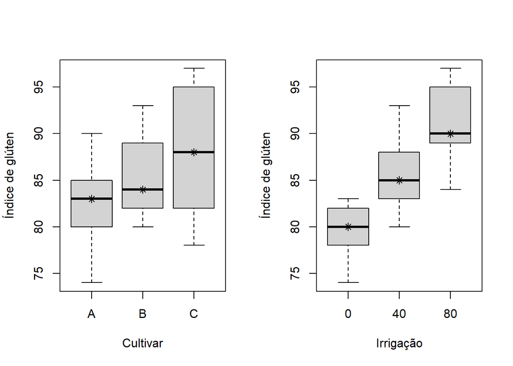

```r
par(mfrow=c(1,2))
boxplot(split(y,cult),   style.bxp="old", xlab="Cultivar",  ylab="Índice de glúten", medchar = T, medpch = 8)
boxplot(split(y,irr), style.bxp="old", xlab="Irrigação", ylab="Índice de glúten", medchar = T, medpch = 8)
```

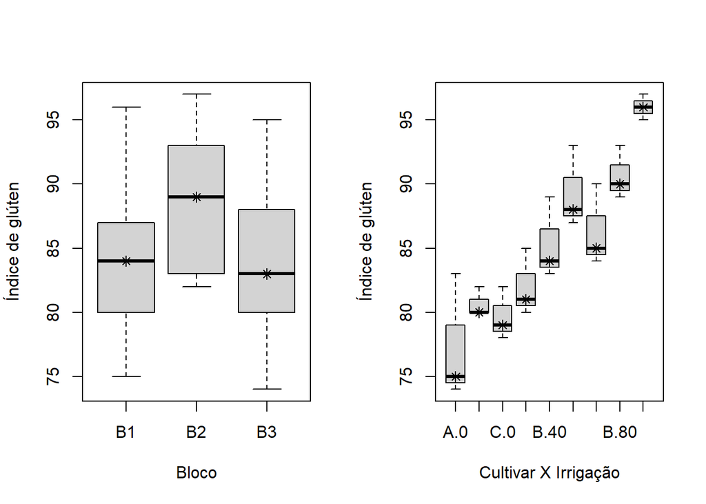

```r
par(mfrow=c(1,2))
boxplot(split(y,bloco),     style.bxp="old", xlab="Bloco",     ylab="Índice de glúten", medchar = T, medpch = 8)
boxplot((y~cult*irr), style.bxp="old", xlab="Cultivar X Irrigação", ylab="Índice de glúten", medchar = T, medpch = 8)
```

## ANOVA

```r
ind.lm <- lm(y ~ bloco + cult*irr)
anova(ind.lm , test="F")
```

```
## Analysis of Variance Table
##
## Response: y
##           Df Sum Sq Mean Sq  F value    Pr(>F)
## bloco      2 119.41  59.704  35.0435 1.424e-06 ***
## cult       2 188.07  94.037  55.1957 6.595e-08 ***
## irr        2 625.41 312.704 183.5435 9.259e-12 ***
## cult:irr   4  51.04  12.759   7.4891  0.001342 **
## Residuals 16  27.26   1.704
## ---
## Signif. codes:  0 '***' 0.001 '**' 0.01 '*' 0.05 '.' 0.1 ' ' 1
```

## modelo para as doses de adubação

```r
ind.aov  <- aov(y~bloco + cult*irr + Error(bloco:cult))
ind.aov
```

```
##
## Call:
## aov(formula = y ~ bloco + cult * irr + Error(bloco:cult))
##
## Grand Mean: 85.25926
##
## Stratum 1: bloco:cult
##
## Terms:
##                     bloco      cult Residuals
## Sum of Squares  119.40741 188.07407   9.03704
## Deg. of Freedom         2         2         4
##
## Residual standard error: 1.503083
## 4 out of 8 effects not estimable
## Estimated effects may be unbalanced
##
## Stratum 2: Within
##
## Terms:
##                      irr cult:irr Residuals
## Sum of Squares  625.4074  51.0370   18.2222
## Deg. of Freedom        2        4        12
##
## Residual standard error: 1.232282
## Estimated effects may be unbalanced
```

```r
summary(ind.aov)
```

```
##
## Error: bloco:cult
##           Df Sum Sq Mean Sq F value  Pr(>F)
## bloco      2 119.41   59.70   26.43 0.00495 **
## cult       2 188.07   94.04   41.62 0.00210 **
## Residuals  4   9.04    2.26
## ---
## Signif. codes:  0 '***' 0.001 '**' 0.01 '*' 0.05 '.' 0.1 ' ' 1
##
## Error: Within
##           Df Sum Sq Mean Sq F value   Pr(>F)
## irr        2  625.4  312.70 205.927 5.15e-10 ***
## cult:irr   4   51.0   12.76   8.402   0.0018 **
## Residuals 12   18.2    1.52
## ---
## Signif. codes:  0 '***' 0.001 '**' 0.01 '*' 0.05 '.' 0.1 ' ' 1
```

## Teste de Tukey

```r
require(laercio)
ind.aov2  <- aov(y~bloco + cult*irr)
LTukey(ind.aov2, which = "trat", conf.level = 0.95)
```

```
##
##  TUKEY TEST TO COMPARE MEANS
##
##  Confidence level:  0.95
##  Dependent variable:  y
##  Variation Coefficient:  1.530931 %
##
## Independent variable:  bloco
##   Factors Means
##   B2      88.2222222222222 a
##   B1      84                b
##   B3      83.5555555555556  b
##
##
## Independent variable:  cult
##   Factors Means
##   C       88.3333333333333 a
##   B       85.5555555555556  b
##   A       81.8888888888889   c
##
##
## Independent variable:  irr
##   Factors Means
##   80      91               a
##   40      85.5555555555556  b
##   0       79.2222222222222   c
##
##
```

# questão 4

experimento em blocos no esquema fatorial subdivido com 2 fatores.  
época de colheita sendo eles: 31-05 (B1), 14-06 (B2), 28-06 (B3), 12-07 (B4), 26-07 (B5), 10-08 (B6).  
E 2 tipos de cultivares sendo eles: pano e chão. Com 3 blocos.

## inserindo os dados

```r
  rm(list=ls(all=TRUE))

  y <- c(58,61,66,68,67,70,56,59,60,61,62,63,
       57,63,67,66,69,72,57,58,59,63,61,61,
       59,59,65,69,65,68,54,61,61,59,63,63)

n = length(y)
t <- 12
b <- 3

bloco<- factor(rep(c("B1","B2","B3"),time=c(t,t,t)))
parcelas<- factor(1:n)

k = 6
j = 2


tcolh<- factor(rep(c(1:k), each=j, times=b), labels=c("31-05","14-06","28-06","12-07","26-07","10-08"))
epoca<- factor(rep(c(1:2), times= k*b), labels=c("pano", "chão"))
trat<- factor(rep(c(1:t), time=b), labels=c("T1","T2","T3","T4","T5","T6","T7","T8","T9","T10","T11","T12"))

DBC<- data.frame(parcelas,bloco,tcolh,epoca,trat,y);  DBC
```

```
##    parcelas bloco tcolh epoca trat  y
## 1         1    B1 31-05  pano   T1 58
## 2         2    B1 31-05  chão   T2 61
## 3         3    B1 14-06  pano   T3 66
## 4         4    B1 14-06  chão   T4 68
## 5         5    B1 28-06  pano   T5 67
## 6         6    B1 28-06  chão   T6 70
## 7         7    B1 12-07  pano   T7 56
## 8         8    B1 12-07  chão   T8 59
## 9         9    B1 26-07  pano   T9 60
## 10       10    B1 26-07  chão  T10 61
## 11       11    B1 10-08  pano  T11 62
## 12       12    B1 10-08  chão  T12 63
## 13       13    B2 31-05  pano   T1 57
## 14       14    B2 31-05  chão   T2 63
```

[output cut: 22 more lines]

## Análise descritiva

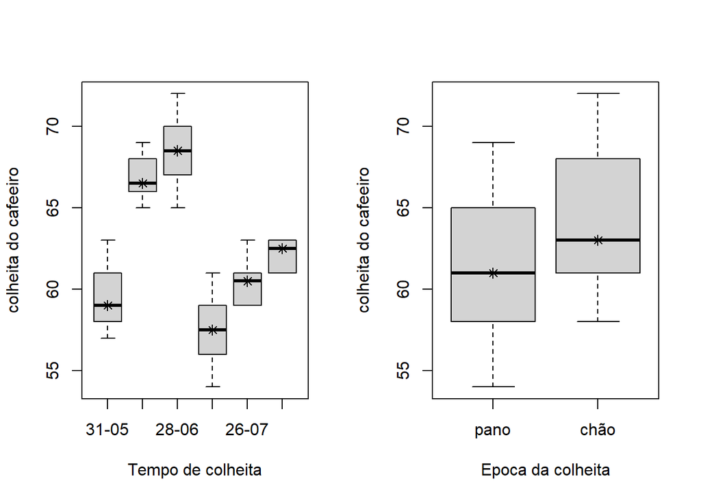

```r
par(mfrow=c(1,2))
boxplot(split(y,tcolh),   style.bxp="old", xlab="Tempo de colheita",  ylab="colheita do cafeeiro", medchar = T, medpch = 8)
boxplot(split(y,epoca), style.bxp="old", xlab="Epoca da colheita", ylab="colheita do cafeeiro", medchar = T, medpch = 8)
```

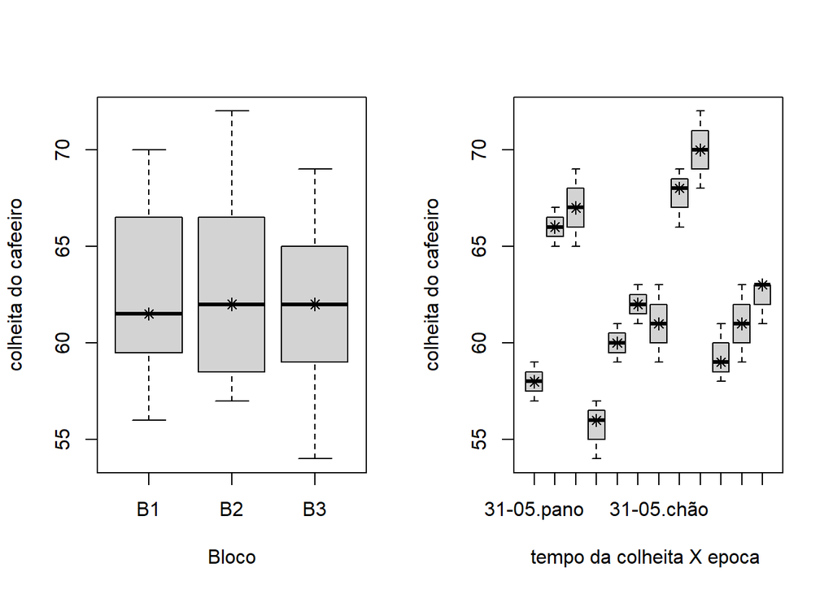

```r
par(mfrow=c(1,2))
boxplot(split(y,bloco),     style.bxp="old", xlab="Bloco",     ylab="colheita do cafeeiro", medchar = T, medpch = 8)
boxplot((y~tcolh*epoca), style.bxp="old", xlab="tempo da colheita X epoca ", ylab="colheita do cafeeiro", medchar = T, medpch = 8)
```

## gráficos de interação

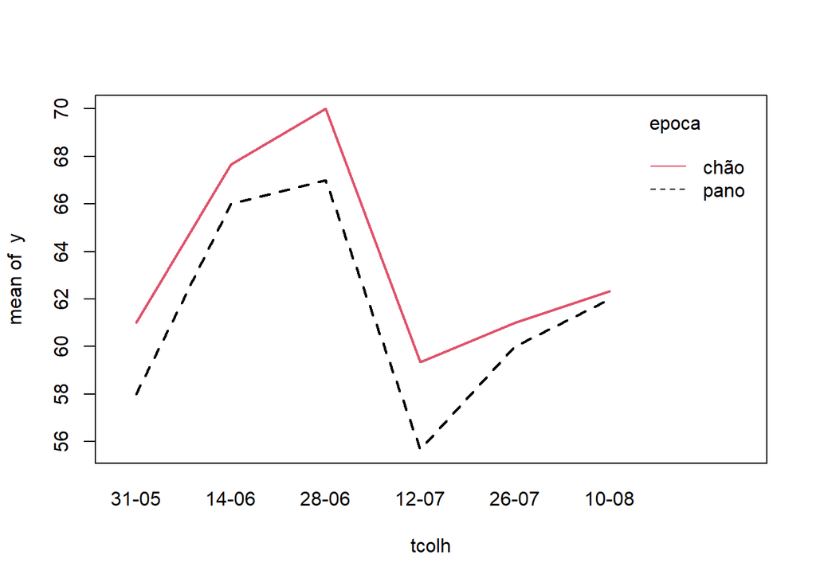

```r
par(mfrow=c(1,1))
interaction.plot(tcolh,epoca,y, lwd=2, col= c("1", "2"))
```

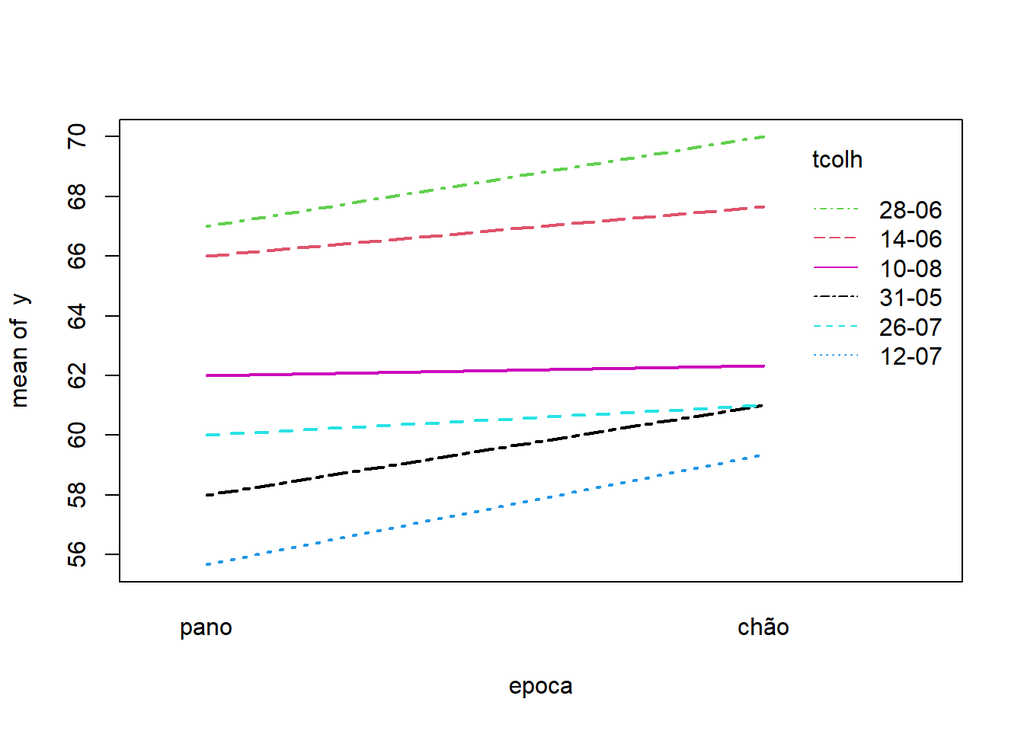

```r
interaction.plot(epoca,tcolh,y, lwd=2, col= c("1", "2", "3", "4", "5", "6"))
```

## ANOVA

```r
mod.lm <- lm(y ~ bloco + tcolh*epoca)
anova(mod.lm , test="F")
```

```
## Analysis of Variance Table
##
## Response: y
##             Df Sum Sq Mean Sq F value    Pr(>F)
## bloco        2   2.17   1.083  0.4373  0.651264
## tcolh        5 557.33 111.467 44.9957 7.948e-11 ***
## epoca        1  40.11  40.111 16.1916  0.000569 ***
## tcolh:epoca  5  12.89   2.578  1.0406  0.418935
## Residuals   22  54.50   2.477
## ---
## Signif. codes:  0 '***' 0.001 '**' 0.01 '*' 0.05 '.' 0.1 ' ' 1
```

```r
mod2.aov  <- aov(y~bloco + tcolh*epoca + Error(bloco:tcolh))
mod2.aov
```

```
##
## Call:
## aov(formula = y ~ bloco + tcolh * epoca + Error(bloco:tcolh))
##
## Grand Mean: 62.5
##
## Stratum 1: bloco:tcolh
##
## Terms:
##                    bloco    tcolh Residuals
## Sum of Squares    2.1667 557.3333   20.5000
## Deg. of Freedom        2        5        10
##
## Residual standard error: 1.431782
## 5 out of 12 effects not estimable
## Estimated effects may be unbalanced
##
## Stratum 2: Within
##
## Terms:
##                    epoca tcolh:epoca Residuals
## Sum of Squares  40.11111    12.88889  34.00000
## Deg. of Freedom        1           5        12
##
## Residual standard error: 1.683251
## Estimated effects may be unbalanced
```

```r
summary(mod2.aov)
```

```
##
## Error: bloco:tcolh
##           Df Sum Sq Mean Sq F value  Pr(>F)
## bloco      2    2.2    1.08   0.528   0.605
## tcolh      5  557.3  111.47  54.374 6.3e-07 ***
## Residuals 10   20.5    2.05
## ---
## Signif. codes:  0 '***' 0.001 '**' 0.01 '*' 0.05 '.' 0.1 ' ' 1
##
## Error: Within
##             Df Sum Sq Mean Sq F value  Pr(>F)
## epoca        1  40.11   40.11   14.16 0.00271 **
## tcolh:epoca  5  12.89    2.58    0.91 0.50634
## Residuals   12  34.00    2.83
## ---
## Signif. codes:  0 '***' 0.001 '**' 0.01 '*' 0.05 '.' 0.1 ' ' 1
```

## Teste de Tukey

```r
require(laercio)
mod3  <- aov(y~bloco + tcolh*epoca)
LTukey(mod3, which = "trat", conf.level = 0.95)
```

```
##
##  TUKEY TEST TO COMPARE MEANS
##
##  Confidence level:  0.95
##  Dependent variable:  y
##  Variation Coefficient:  2.518297 %
##
## Independent variable:  bloco
##   Factors Means
##   B2      62.75            a
##   B1      62.5833333333333 a
##   B3      62.1666666666667 a
##
##
## Independent variable:  tcolh
##   Factors Means
##   28-06   68.5             a
##   14-06   66.8333333333333 a
##   10-08   62.1666666666667  b
##   26-07   60.5              b
##   31-05   59.5              bc
##   12-07   57.5               c
##
##
## Independent variable:  epoca
##   Factors Means
##   chão    63.5555555555556 a
##   pano    61.4444444444444  b
##
##
```

# questão 5

experimento em blocos no esquema fatorial subdivido com 2 fatores e 2 blocos.  
Sendo 4 tipos de tratamentos sendo eles: AR, AR + AE, AM e AM + AE.  
E 2 diferentes temperaturas sendo elas: 12ºC (B1) e 25ºC (B2).

## inserindo os dados

```r
rm(list=ls(all=TRUE))

y <- c(7.0,7.0,5.7,6.6,6.2,9.4,7.1,10.5,
       6.5,6.7,5.4,6.9,5.8,8.9,6.5,9.6)

n = length(y)
t <- 8
b <- 2


Bloco<- factor(rep(c("B1","B2"),time=c(t,t)))

parcelas<- factor(1:n)

k = 4
j = 2

Fator2<- factor(rep(c(1:k), each=j, times=b), labels=c("AR", "AR + AE", "AM", "AM + AE"))
Fator1<- factor(rep(c(1:2), times= k*b), labels=c("12ºC", "25ºC"))
Tratamento<- factor(rep(c(1:t), time=b), labels=c("T1","T2","T3","T4","T5","T6","T7","T8"))

DBC<- data.frame(Fator1, Fator2, Bloco,y);  DBC
```

```
##    Fator1  Fator2 Bloco    y
## 1    12ºC      AR    B1  7.0
## 2    25ºC      AR    B1  7.0
## 3    12ºC AR + AE    B1  5.7
## 4    25ºC AR + AE    B1  6.6
## 5    12ºC      AM    B1  6.2
## 6    25ºC      AM    B1  9.4
## 7    12ºC AM + AE    B1  7.1
## 8    25ºC AM + AE    B1 10.5
## 9    12ºC      AR    B2  6.5
## 10   25ºC      AR    B2  6.7
## 11   12ºC AR + AE    B2  5.4
## 12   25ºC AR + AE    B2  6.9
## 13   12ºC      AM    B2  5.8
## 14   25ºC      AM    B2  8.9
## 15   12ºC AM + AE    B2  6.5
## 16   25ºC AM + AE    B2  9.6
```

## análise

```r
require(ExpDes.pt)
psub2.dbc(Fator1, Fator2, Bloco, y, quali = c(TRUE, TRUE),
          mcomp = "tukey", fac.names = c("Tratamento", "Subtratamento"),
          sigT = 0.05, sigF = 0.05)
```

```
## ------------------------------------------------------------------------
## Legenda:
## FATOR 1 (parcela):  Tratamento
## FATOR 2 (subparcela):  Subtratamento
## ------------------------------------------------------------------------
##
## ------------------------------------------------------------------------
## $`Quadro da analise de variancia\n------------------------------------------------------------------------\n`
##                          GL     SQ      QM      Fc  Pr(>Fc)
## Tratamento                1 14.822 14.8225 1482.25 0.016532 *
## Bloco                     1  0.640  0.6400   64.00 0.079167 .
## Erro a                    1  0.010  0.0100
## Subtratamento             3 11.592  3.8642   57.96    8e-05 ***
## Tratamento*Subtratamento  3  7.112  2.3708   35.56 0.000324 ***
## Erro b                    6  0.400  0.0667
## Total                    15 34.578
## ---
## Signif. codes:  0 '***' 0.001 '**' 0.01 '*' 0.05 '.' 0.1 ' ' 1
##
## ------------------------------------------------------------------------
## CV 1 = 1.381693 %
## CV 2 = 3.567515 %
##
##
##
## Interacao significativa: desdobrando a interacao
## ------------------------------------------------------------------------
##
## Desdobrando  Tratamento  dentro de cada nivel de  Subtratamento
## ------------------------------------------------------------------------
##                                           GL        SQ      QM         Fc
## Tratamento : Subtratamento AR       1.000000  0.010000  0.0100   0.190475
## Tratamento : Subtratamento AR + AE  1.000000  1.440000  1.4400  27.428441
## Tratamento : Subtratamento AM       1.000000  9.922500  9.9225   188.9991
## Tratamento : Subtratamento AM + AE  1.000000 10.562500 10.5625 201.189518
## Erro combinado                      6.517239  0.342155  0.0525
##                                      valor.p
## Tratamento : Subtratamento AR       0.676612
## Tratamento : Subtratamento AR + AE  0.001505
## Tratamento : Subtratamento AM          5e-06
```

[output cut: 60 more lines]

```
## ------------------------------------------------------------------------
## ------------------------------------------------------------------------
##
##
##  Subtratamento dentro de Tratamento 25ºC
## ------------------------------------------------------------------------
## Teste de Tukey
## ------------------------------------------------------------------------
## Grupos Tratamentos Medias
## a     AM + AE     10.05
##  b    AM      9.15
##   c   AR      6.85
##   c   AR + AE     6.75
## ------------------------------------------------------------------------
## ------------------------------------------------------------------------
```

## boxplot

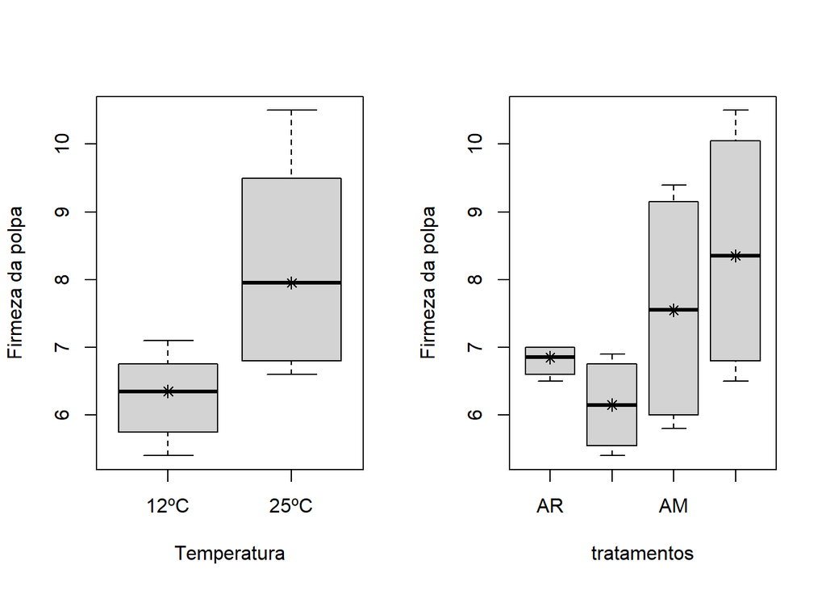

```r
par(mfrow=c(1,2))
boxplot(split(y,Fator1),   style.bxp="old", xlab="Temperatura",  ylab="Firmeza da polpa", medchar = T, medpch = 8)
boxplot(split(y,Fator2), style.bxp="old", xlab="tratamentos", ylab="Firmeza da polpa", medchar = T, medpch = 8)
```

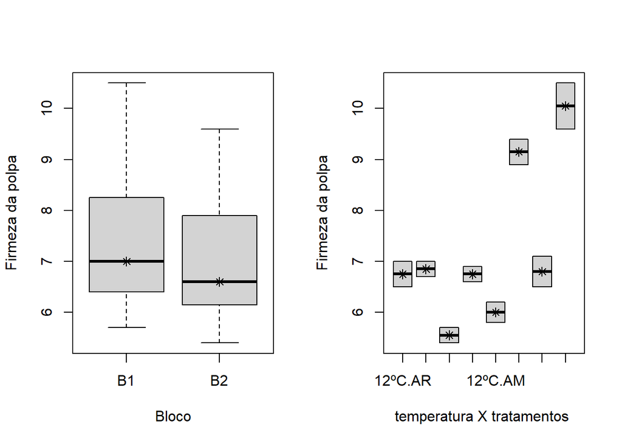

```r
par(mfrow=c(1,2))
boxplot(split(y,Bloco),     style.bxp="old", xlab="Bloco",     ylab="Firmeza da polpa", medchar = T, medpch = 8)
boxplot((y~Fator1*Fator2), style.bxp="old", xlab="temperatura X tratamentos ", ylab="Firmeza da polpa", medchar = T, medpch = 8)
```

#questão 6

## inserindo os dados

```r
y <- c(53,58,80,28,25,55,28,47,58,33,35,77,55,68,40,
       57,64,84,32,29,66,32,51,64,37,37,71,53,64,42)

n = length(y)
t <- 15
rep <- 2

repi<- factor(rep(c("R1","R2"),time=c(t,t)))
parcelas<- factor(1:n)

k = 5
j = 3


ins<- factor(rep(c(1:k), each=j, times=rep), labels=c("Decis FW","mipcin 4G", "mipcin 2GF","toxafeno","lorsban"))
man<- factor(rep(c(1:3), times= k*rep), labels=c("1 dia","8 dias","15 dias"))
trat<- factor(rep(c(1:t), time=rep), labels=c("T1","T2","T3","T4","T5","T6","T7","T8","T9","T10","T11","T12","T13","T14","T15"))

DBC<- data.frame(parcelas,repi,ins,man,trat,y);  DBC
```

```
##    parcelas repi        ins     man trat  y
## 1         1   R1   Decis FW   1 dia   T1 53
## 2         2   R1   Decis FW  8 dias   T2 58
## 3         3   R1   Decis FW 15 dias   T3 80
## 4         4   R1  mipcin 4G   1 dia   T4 28
## 5         5   R1  mipcin 4G  8 dias   T5 25
## 6         6   R1  mipcin 4G 15 dias   T6 55
## 7         7   R1 mipcin 2GF   1 dia   T7 28
## 8         8   R1 mipcin 2GF  8 dias   T8 47
## 9         9   R1 mipcin 2GF 15 dias   T9 58
## 10       10   R1   toxafeno   1 dia  T10 33
## 11       11   R1   toxafeno  8 dias  T11 35
## 12       12   R1   toxafeno 15 dias  T12 77
## 13       13   R1    lorsban   1 dia  T13 55
## 14       14   R1    lorsban  8 dias  T14 68
```

[output cut: 16 more lines]

## Análise descritiva

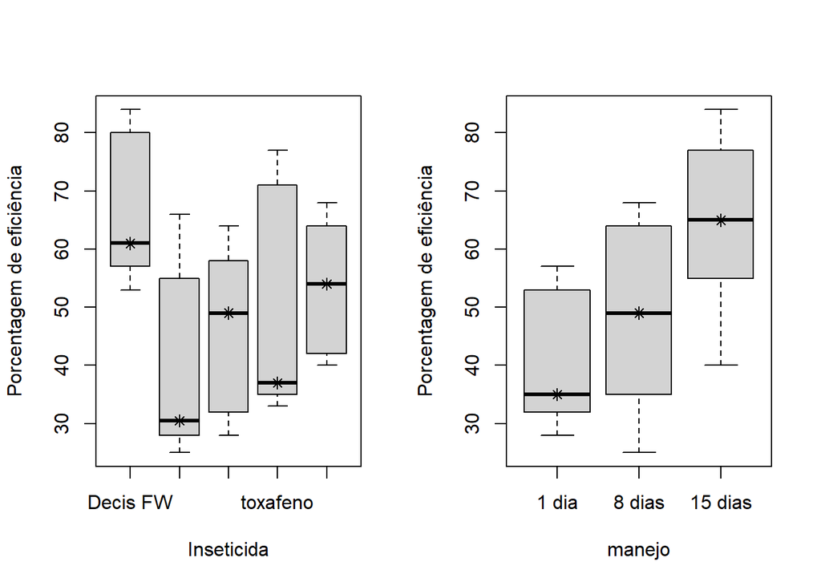

```r
par(mfrow=c(1,2))
boxplot(split(y,ins),   style.bxp="old", xlab="Inseticida",  ylab="Porcentagem de eficiência", medchar = T, medpch = 8)
boxplot(split(y,man), style.bxp="old", xlab="manejo", ylab="Porcentagem de eficiência", medchar = T, medpch = 8)
```

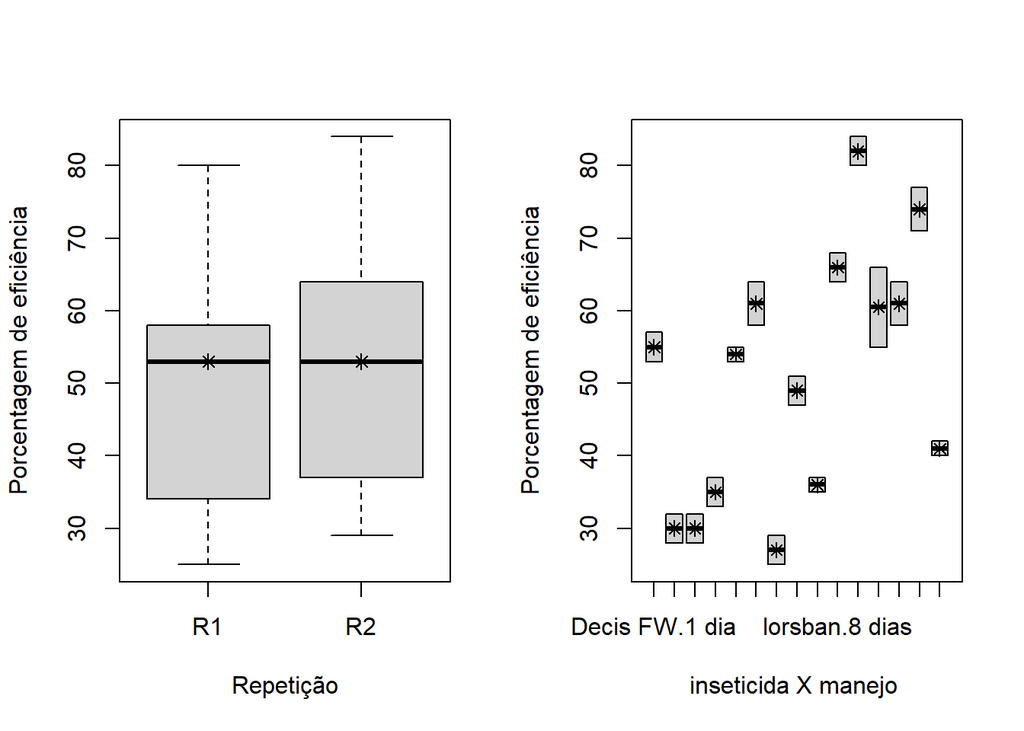

```r
par(mfrow=c(1,2))
boxplot(split(y,repi),     style.bxp="old", xlab="Repetição",     ylab="Porcentagem de eficiência", medchar = T, medpch = 8)
boxplot((y~ins*man), style.bxp="old", xlab="inseticida X manejo ", ylab="Porcentagem de eficiência", medchar = T, medpch = 8)
```

## gráfico de interação

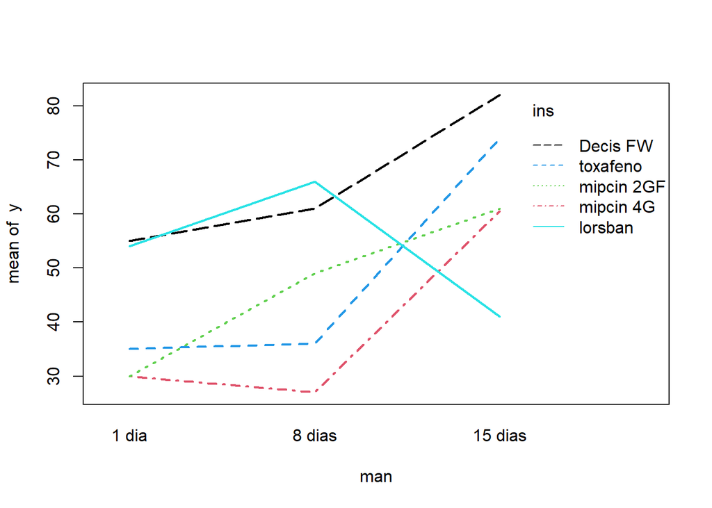

```r
par(mfrow=c(1,1))
interaction.plot(man,ins,y, lwd=2, col= c("1", "2", "3", "4", "5"))
```

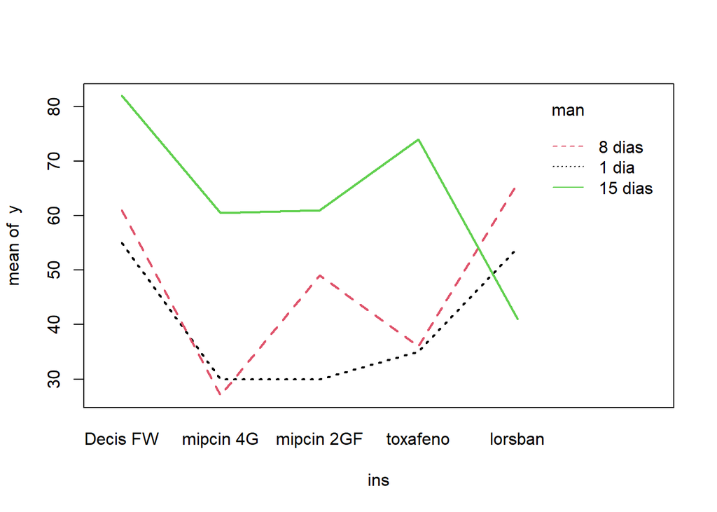

```r
interaction.plot(ins,man,y, lwd=2, col= c("1", "2", "3"))
```

## Analise

```r
require(ExpDes.pt)

psub2.dbc(ins, man, repi, y, quali = c(TRUE, TRUE),
          mcomp = "tukey", fac.names = c("inseticida", "dias"),
          sigT = 0.05, sigF = 0.05)
```

```
## ------------------------------------------------------------------------
## Legenda:
## FATOR 1 (parcela):  inseticida
## FATOR 2 (subparcela):  dias
## ------------------------------------------------------------------------
##
## ------------------------------------------------------------------------
## $`Quadro da analise de variancia\n------------------------------------------------------------------------\n`
##                 GL     SQ      QM      Fc   Pr(>Fc)
## inseticida       4 2386.5  596.63  35.870  0.002167 **
## Bloco            1   61.6   61.63   3.705  0.126549
## Erro a           4   66.5   16.63
## dias             2 2754.1 1377.03 244.444 < 2.2e-16 ***
## inseticida*dias  8 3004.3  375.53  66.663 < 2.2e-16 ***
## Erro b          10   56.3    5.63
## Total           29 8329.4
## ---
## Signif. codes:  0 '***' 0.001 '**' 0.01 '*' 0.05 '.' 0.1 ' ' 1
##
## ------------------------------------------------------------------------
## CV 1 = 8.033615 %
## CV 2 = 4.675242 %
##
##
##
## Interacao significativa: desdobrando a interacao
## ------------------------------------------------------------------------
##
## Desdobrando  inseticida  dentro de cada nivel de  dias
## ------------------------------------------------------------------------
##                                  GL         SQ    QM        Fc valor.p
## inseticida : dias 1 dia    4.000000 1285.60000 321.4 34.559141 1.2e-05
## inseticida : dias 8 dias   4.000000 2157.60000 539.4 58.000002   1e-06
## inseticida : dias 15 dias  4.000000 1947.60000 486.9 52.354841   2e-06
## Erro combinado             9.508956   88.43329   9.3
## ------------------------------------------------------------------------
##
##
##  inseticida dentro de dias 1 dia
## ------------------------------------------------------------------------
```

[output cut: 90 more lines]

```
##  b    1 dia   35
## ------------------------------------------------------------------------
## ------------------------------------------------------------------------
##
##
##  dias dentro de inseticida lorsban
## ------------------------------------------------------------------------
## Teste de Tukey
## ------------------------------------------------------------------------
## Grupos Tratamentos Medias
## a     8 dias      66
##  b    1 dia   54
##   c   15 dias     41
## ------------------------------------------------------------------------
## ------------------------------------------------------------------------
```